# Graded Novelty Encoding Task - pilot analysis

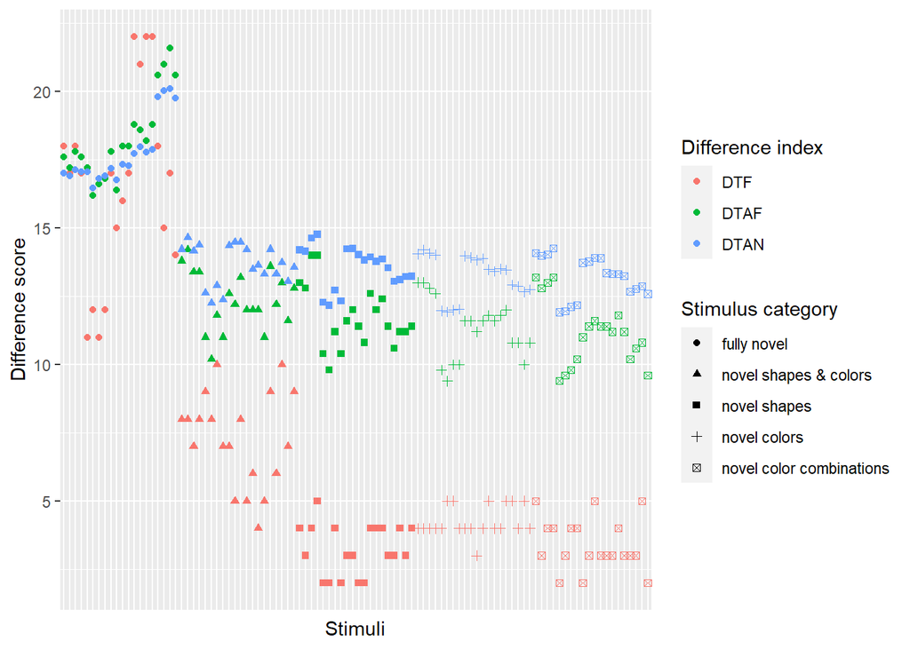

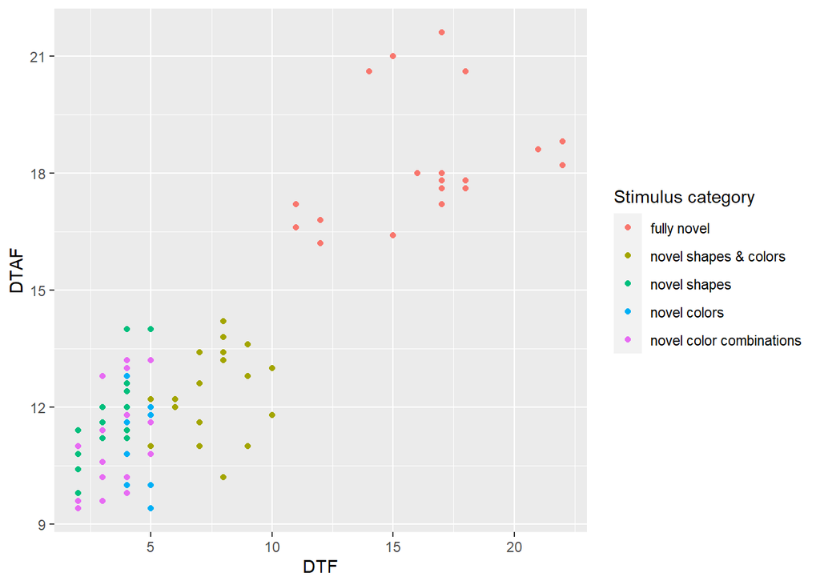

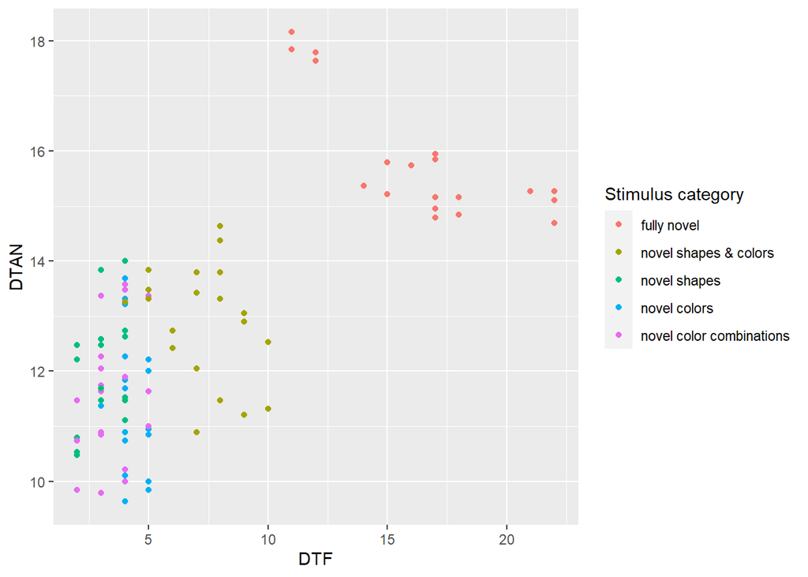

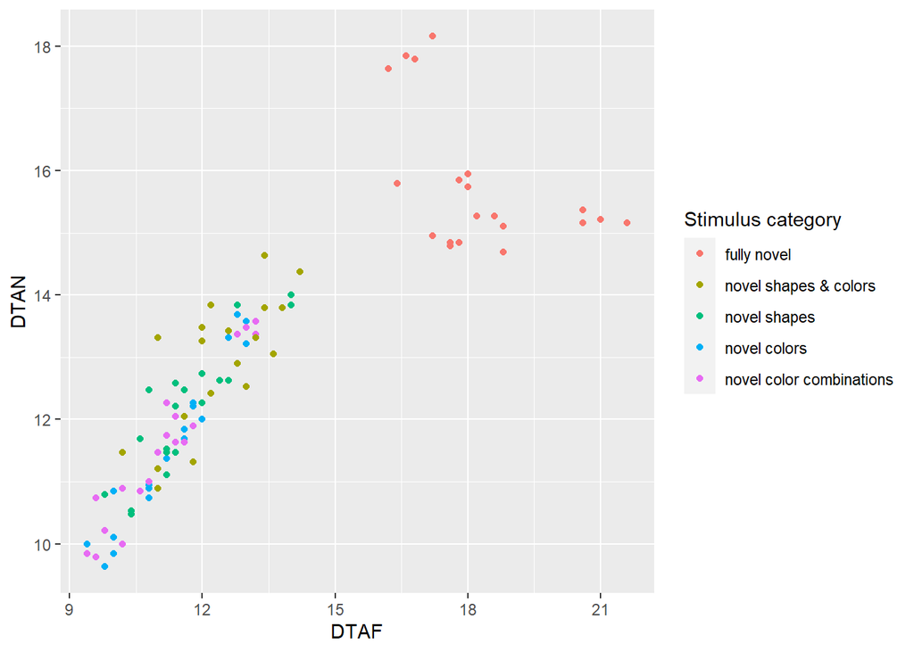

# Study phase:

During the study phase, the participants see familiar and novel items.

The participants produced a mean (±sd) recognition rate of 0.6586667 ± 0.1666619 for familiar pictures.

The participants produced a mean (±sd) corrected recognition rate of 0.3973333 ± 0.2131211 for familiar pictures.

Uncorrected: The sample performed above chance levels, as a one sample t-test showed (t(209)=13.7961814, p = 1.6389635^{-31}, Cohen’s d = 0.952027, 95% CI:0.6649518 - 1.2391021).

Corrected: The sample performed above chance levels, as a one sample t-test showed (t(209)=27.0170661, p = 2.0413423^{-70}, Cohen’s d = 1.8643547, 95% CI:1.5384899 - 2.1902195).

We use an ANOVA to see if there is a difference in correct rejection for the different novels.

```
## Anova Table (Type 3 tests)
##
## Response: N
##   Effect           df  MSE         F  ges p.value
## 1   type 3.52, 366.32 1.78 24.87 *** .090   <.001
## ---
## Signif. codes:  0 '***' 0.001 '**' 0.01 '*' 0.05 '+' 0.1 ' ' 1
##
## Sphericity correction method: GG
```

```
##  contrast             estimate    SE  df t.ratio p.value
##  diffarr - sarr          0.838 0.145 104   5.797  <.0001
##  diffarr - sarrcol       0.838 0.157 104   5.328  <.0001
##  diffarr - sarrsha       1.724 0.201 104   8.559  <.0001
##  diffarr - sarrshacol    0.819 0.151 104   5.440  <.0001
##  sarr - sarrcol          0.000 0.154 104   0.000  1.0000
##  sarr - sarrsha          0.886 0.170 104   5.202  <.0001
##  sarr - sarrshacol      -0.019 0.167 104  -0.114  1.0000
##  sarrcol - sarrsha       0.886 0.200 104   4.429  0.0002
##  sarrcol - sarrshacol   -0.019 0.181 104  -0.105  1.0000
##  sarrsha - sarrshacol   -0.905 0.192 104  -4.709  0.0001
##
## P value adjustment: tukey method for comparing a family of 5 estimates
```

```
##  contrast  estimate    SE  df t.ratio p.value
##  linear      -2.524 0.376 104  -6.716  <.0001
##  quadratic    2.600 0.485 104   5.360  <.0001
##  cubic        0.952 0.342 104   2.783  0.0064
##  quartic      4.400 1.096 104   4.014  0.0001
```

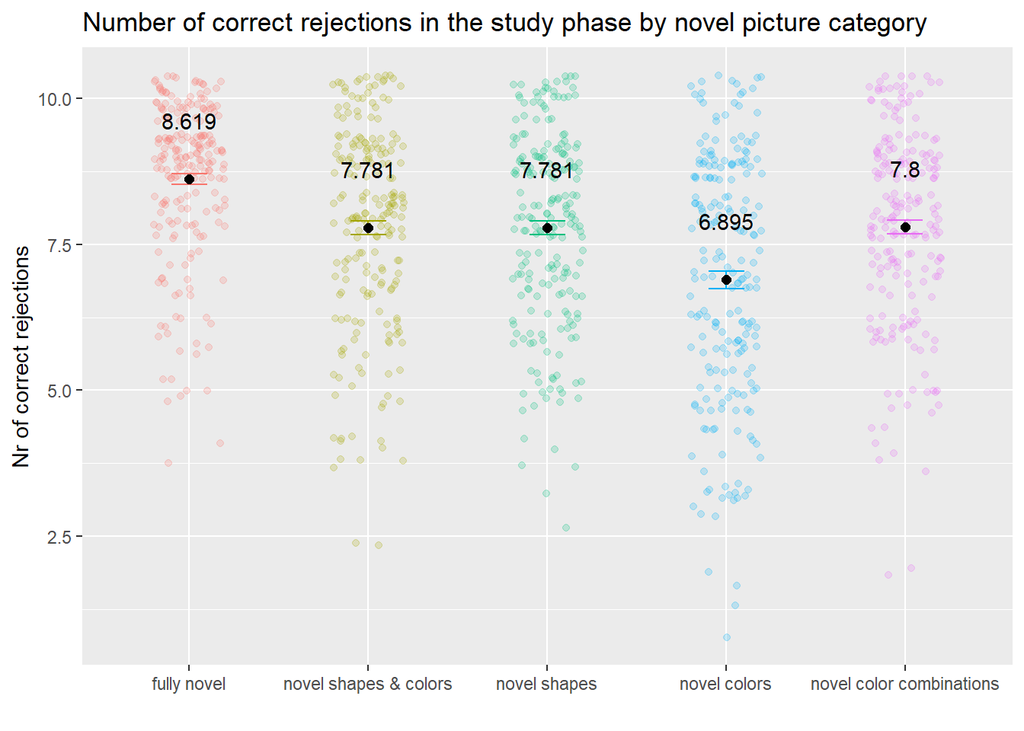

# Test phase:

This phase tests the learning that has occurred during the study phase. If the participants learned the novels in the study phase, their responses should differ for the stimuli that they have already seen during the study phase (familiars) and those that they see for the first time during the test phase (novels). We also let the participants to choose “maybe” by pressing the down arrow, but asked them not to overuse this response (maybe resp <= 50). We added these responses as correct responses to both stimulus categories.

Maybe responses (MEAN ± SD): 12.3142857 ± 9.1392163.

```
## [1] "A t-test to compare the number of old responses btwn old and new stim"
```

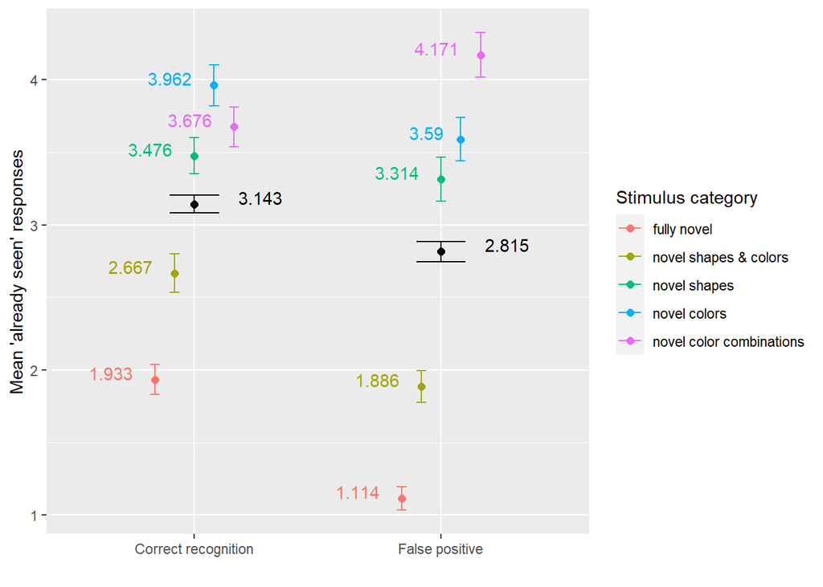

Results of the paired t-test: (t(1049)=5.5959762, p = 2.7991796^{-8}, Cohen’s d = 0.1544533, 95% CI:0.1000037 - 0.2089029).

Shapiro-Wilk is significant (p = 9.4885676^{-14}).

We used a Wilcoxon sgined-rank test. Z = -5.821533, p = 2.9155149^{-9}

## ANOVA - Corrected Recog

```
## Anova Table (Type 3 tests)
##
## Response: CorrRecog
##     Effect           df  MSE        F  ges p.value
## 1 neworder 3.78, 393.25 3.39 9.45 *** .064   <.001
## ---
## Signif. codes:  0 '***' 0.001 '**' 0.01 '*' 0.05 '+' 0.1 ' ' 1
##
## Sphericity correction method: GG
```

```
##  contrast estimate    SE  df t.ratio p.value
##  A - B      0.0381 0.214 104   0.178  0.9998
##  A - C      0.4476 0.238 104   1.885  0.3320
##  A - D      0.6571 0.248 104   2.646  0.0695
##  A - E      1.3143 0.225 104   5.853  <.0001
##  B - C      0.4095 0.233 104   1.760  0.4026
##  B - D      0.6190 0.250 104   2.479  0.1033
##  B - E      1.2762 0.242 104   5.267  <.0001
##  C - D      0.2095 0.266 104   0.786  0.9341
##  C - E      0.8667 0.278 104   3.121  0.0194
##  D - E      0.6571 0.270 104   2.438  0.1136
##
## P value adjustment: tukey method for comparing a family of 5 estimates
```

```
##  contrast  estimate    SE  df t.ratio p.value
##  linear     -3.2476 0.517 104  -6.279  <.0001
##  quadratic  -1.0381 0.706 104  -1.471  0.1442
##  cubic      -0.0762 0.544 104  -0.140  0.8890
##  quartic    -1.2190 1.453 104  -0.839  0.4034
```

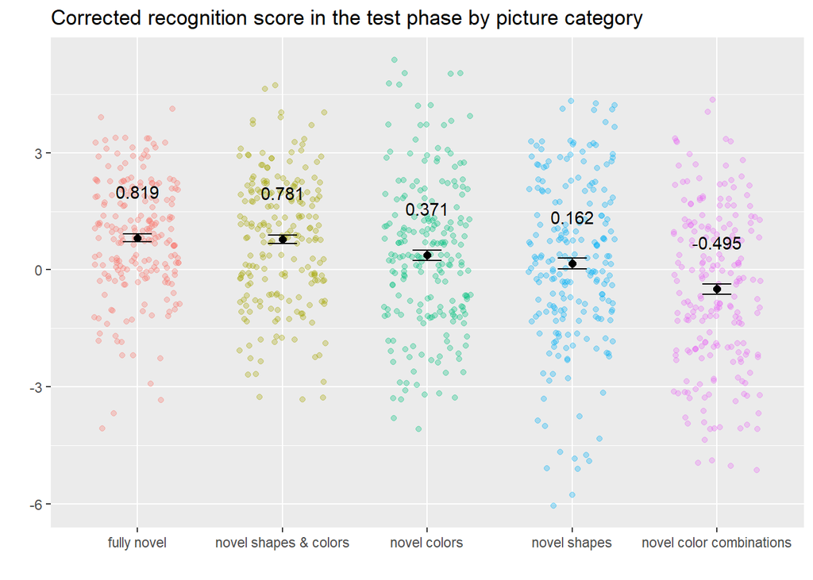

ANOVA (factor: TYPE (5 lvls)): (F[3.7812883,393.2539784] = 9.4474138, p = 4.9846388^{-7}, n2G = 0.0641624).

# Mixed models

The metrics

-DTF - Difference To corresponding Familiar picture All pictures are compared to a familiar. The number of differences between the three vectors of the pictures yields a difference score.

-DTAF - mean Difference To All Familiars We calculate the difference from all prototypes and take the mean for each picture in the set.

-DTN - mean Difference To all other Novels in the same category We calculate the differences between each pair of pictures and then take the mean of these differences (19 comparisons per stim).

## Study phase

With these models i tried to assess which difference index explains familiar v novel distinction in study phase the best. As far as i understand, the model with the smallest AIC fits best to our data, which means that the mean difference from the corresponding familiar worked best here. The models all show, that the more different pictures are categorized with the highest efficacy.

```
## Generalized linear mixed model fit by maximum likelihood (Laplace
##   Approximation) [glmerMod]
##  Family: binomial  ( logit )
## Formula: st_corr ~ DTF + (1 | workerId)
##    Data: stlmm
##
##      AIC      BIC   logLik deviance df.resid
##   8711.4   8732.3  -4352.7   8705.4     7872
##
## Scaled residuals:
##     Min      1Q  Median      3Q     Max
## -4.2181 -1.0675  0.4992  0.6243  1.2260
##
## Random effects:
##  Groups   Name        Variance Std.Dev.
##  workerId (Intercept) 0.2223   0.4715
## Number of obs: 7875, groups:  workerId, 105
##
## Fixed effects:
##             Estimate Std. Error z value Pr(>|z|)
## (Intercept) 0.775083   0.057271   13.53   <2e-16 ***
## DTF         0.076947   0.005926   12.98   <2e-16 ***
## ---
## Signif. codes:  0 '***' 0.001 '**' 0.01 '*' 0.05 '.' 0.1 ' ' 1
##
## Correlation of Fixed Effects:
##     (Intr)
## DTF -0.361
```

```
## Package `effects` is not available, but needed for `ggeffect()`. Either install package `effects`, or use `ggpredict()`. Calling `ggpredict()` now.FALSE
```

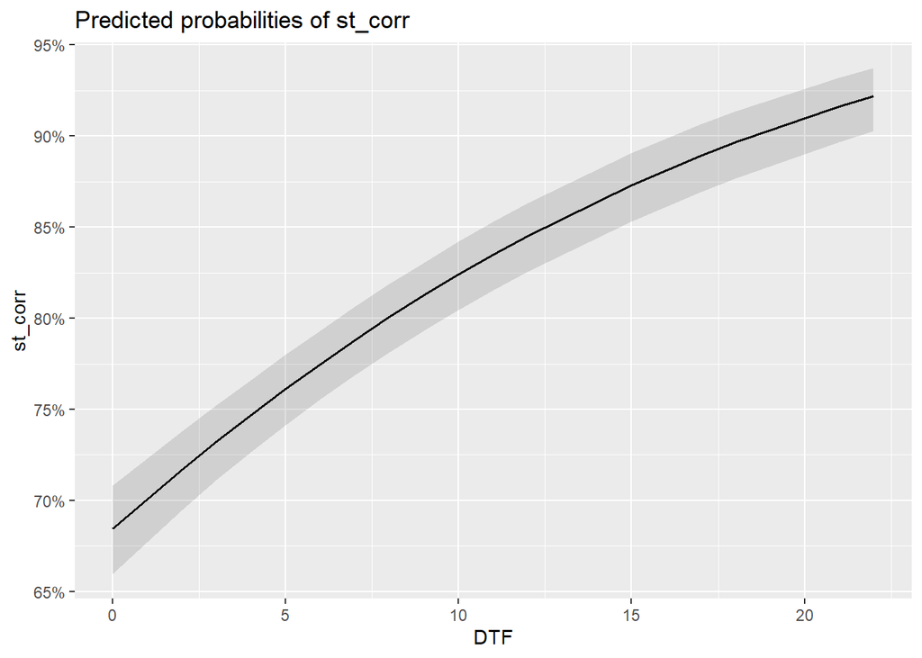

```
## Generalized linear mixed model fit by maximum likelihood (Laplace
##   Approximation) [glmerMod]
##  Family: binomial  ( logit )
## Formula: st_corr ~ DTAF + (1 | workerId)
##    Data: stlmm
##
##      AIC      BIC   logLik deviance df.resid
##   8718.0   8738.9  -4356.0   8712.0     7872
##
## Scaled residuals:
##     Min      1Q  Median      3Q     Max
## -3.5045 -1.0189  0.4791  0.6110  1.3133
##
## Random effects:
##  Groups   Name        Variance Std.Dev.
##  workerId (Intercept) 0.2232   0.4724
## Number of obs: 7875, groups:  workerId, 105
##
## Fixed effects:
##             Estimate Std. Error z value Pr(>|z|)
## (Intercept)  0.63704    0.06146   10.37   <2e-16 ***
## DTAF         0.05559    0.00404   13.76   <2e-16 ***
## ---
## Signif. codes:  0 '***' 0.001 '**' 0.01 '*' 0.05 '.' 0.1 ' ' 1
##
## Correlation of Fixed Effects:
##      (Intr)
## DTAF -0.492
```

```
## Package `effects` is not available, but needed for `ggeffect()`. Either install package `effects`, or use `ggpredict()`. Calling `ggpredict()` now.FALSE
```

```
## Data were 'prettified'. Consider using `terms="DTAF [all]"` to get smooth plots.
```

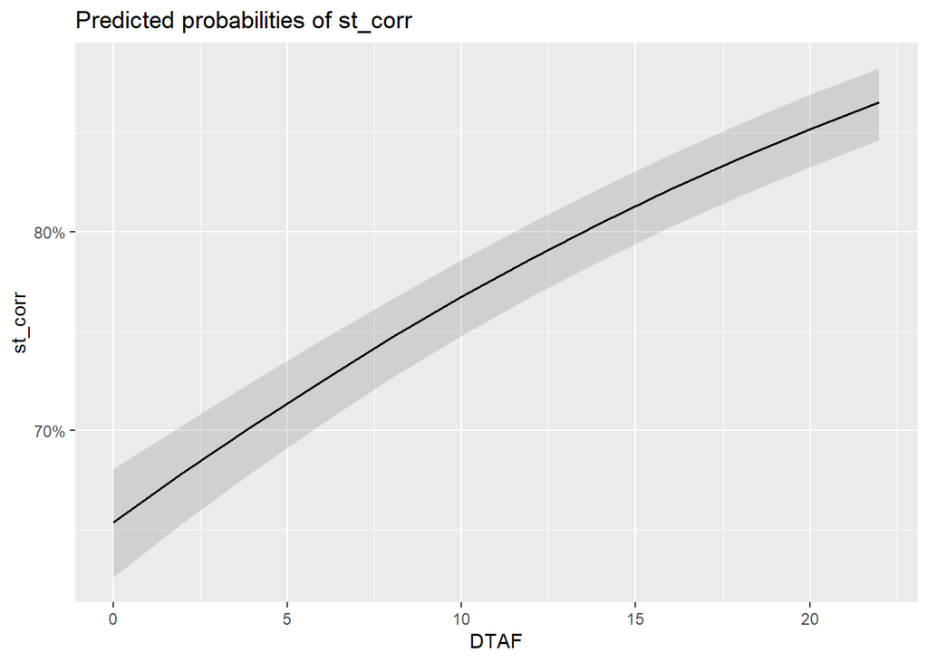

```
## Generalized linear mixed model fit by maximum likelihood (Laplace
##   Approximation) [glmerMod]
##  Family: binomial  ( logit )
## Formula: st_corr ~ DTAN + (1 | workerId)
##    Data: stlmm
##
##      AIC      BIC   logLik deviance df.resid
##   8737.4   8758.3  -4365.7   8731.4     7872
##
## Scaled residuals:
##     Min      1Q  Median      3Q     Max
## -3.5736 -1.0247  0.4824  0.6093  1.3045
##
## Random effects:
##  Groups   Name        Variance Std.Dev.
##  workerId (Intercept) 0.2219   0.4711
## Number of obs: 7875, groups:  workerId, 105
##
## Fixed effects:
##             Estimate Std. Error z value Pr(>|z|)
## (Intercept) 0.646361   0.061849   10.45   <2e-16 ***
## DTAN        0.054450   0.004142   13.14   <2e-16 ***
## ---
## Signif. codes:  0 '***' 0.001 '**' 0.01 '*' 0.05 '.' 0.1 ' ' 1
##
## Correlation of Fixed Effects:
##      (Intr)
## DTAN -0.505
```

```
## Package `effects` is not available, but needed for `ggeffect()`. Either install package `effects`, or use `ggpredict()`. Calling `ggpredict()` now.FALSE
```

```
## Data were 'prettified'. Consider using `terms="DTAN [all]"` to get smooth plots.
```

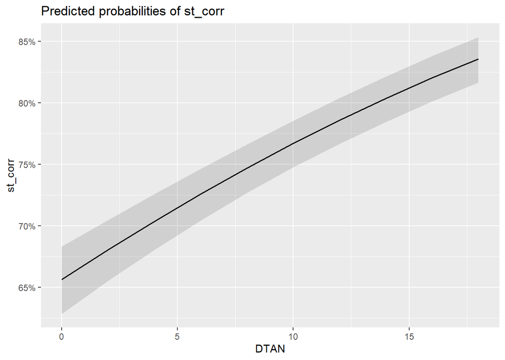

|  | st_corr |  |  |  | st_corr |  |  |  | st_corr |  |  |  |
| --- | --- | --- | --- | --- | --- | --- | --- | --- | --- | --- | --- | --- |
| Predictors | Log-Odds | std. Error | CI | p | Log-Odds | std. Error | CI | p | Log-Odds | std. Error | CI | p |
| (Intercept) | 0.78 | 0.06 | 0.66 – 0.89 | **<0.001** | 0.64 | 0.06 | 0.52 – 0.76 | **<0.001** | 0.65 | 0.06 | 0.53 – 0.77 | **<0.001** |
| DTF | 0.08 | 0.01 | 0.07 – 0.09 | **<0.001** |  |  |  |  |  |  |  |  |
| DTAF |  |  |  |  | 0.06 | 0.00 | 0.05 – 0.06 | **<0.001** |  |  |  |  |
| DTAN |  |  |  |  |  |  |  |  | 0.05 | 0.00 | 0.05 – 0.06 | **<0.001** |
| Random Effects |  |  |  |  |  |  |  |  |  |  |  |  |
| σ<sup>2</sup> | 3.29 |  |  |  | 3.29 |  |  |  | 3.29 |  |  |  |
| τ<sub>00</sub> | 0.22 <sub>workerId</sub> |  |  |  | 0.22 <sub>workerId</sub> |  |  |  | 0.22 <sub>workerId</sub> |  |  |  |
| ICC | 0.06 |  |  |  | 0.06 |  |  |  | 0.06 |  |  |  |
| N | 105 <sub>workerId</sub> |  |  |  | 105 <sub>workerId</sub> |  |  |  | 105 <sub>workerId</sub> |  |  |  |
| Observations | 7875 |  |  |  | 7875 |  |  |  | 7875 |  |  |  |
| Marginal R<sup>2</sup> / Conditional R<sup>2</sup> | 0.048 / 0.108 |  |  |  | 0.036 / 0.097 |  |  |  | 0.032 / 0.093 |  |  |  |
| AIC | 8711.361 |  |  |  | 8718.015 |  |  |  | 8737.387 |  |  |  |
| AICc | 8711.364 |  |  |  | 8718.018 |  |  |  | 8737.390 |  |  |  |

## Test phase

### Models #1 - without random slope term

Logistic mixed regression for the test phase. Does difference from prototypes or familiarity/novelty have an effect on correct categorization in the test phase?

```
## Generalized linear mixed model fit by maximum likelihood (Laplace
##   Approximation) [glmerMod]
##  Family: binomial  ( logit )
## Formula: rt_resp ~ DTF * tq + (1 | workerId)
##    Data: tdlmm
##
##      AIC      BIC   logLik deviance df.resid
##  10014.7  10049.8  -5002.3  10004.7     8277
##
## Scaled residuals:
##     Min      1Q  Median      3Q     Max
## -2.3281 -0.7603 -0.4538  0.9484  6.6943
##
## Random effects:
##  Groups   Name        Variance Std.Dev.
##  workerId (Intercept) 0.4103   0.6405
## Number of obs: 8282, groups:  workerId, 105
##
## Fixed effects:
##             Estimate Std. Error z value Pr(>|z|)
## (Intercept)  0.32390    0.08804   3.679 0.000234 ***
## DTF         -0.14641    0.00872 -16.791  < 2e-16 ***
## tqold       -0.25535    0.08264  -3.090 0.002004 **
## DTF:tqold    0.06272    0.01112   5.640  1.7e-08 ***
## ---
## Signif. codes:  0 '***' 0.001 '**' 0.01 '*' 0.05 '.' 0.1 ' ' 1
##
## Correlation of Fixed Effects:
##           (Intr) DTF    tqold
## DTF       -0.575
## tqold     -0.525  0.612
## DTF:tqold  0.450 -0.781 -0.807
```

```
## Package `effects` is not available, but needed for `ggeffect()`. Either install package `effects`, or use `ggpredict()`. Calling `ggpredict()` now.FALSE
```

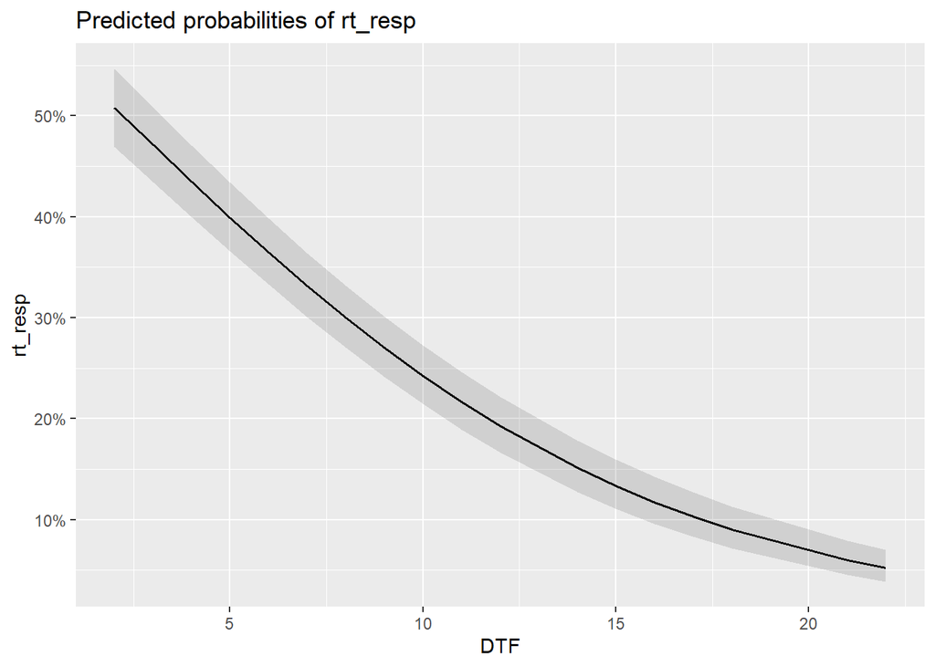

```
## Package `effects` is not available, but needed for `ggeffect()`. Either install package `effects`, or use `ggpredict()`. Calling `ggpredict()` now.FALSE
```

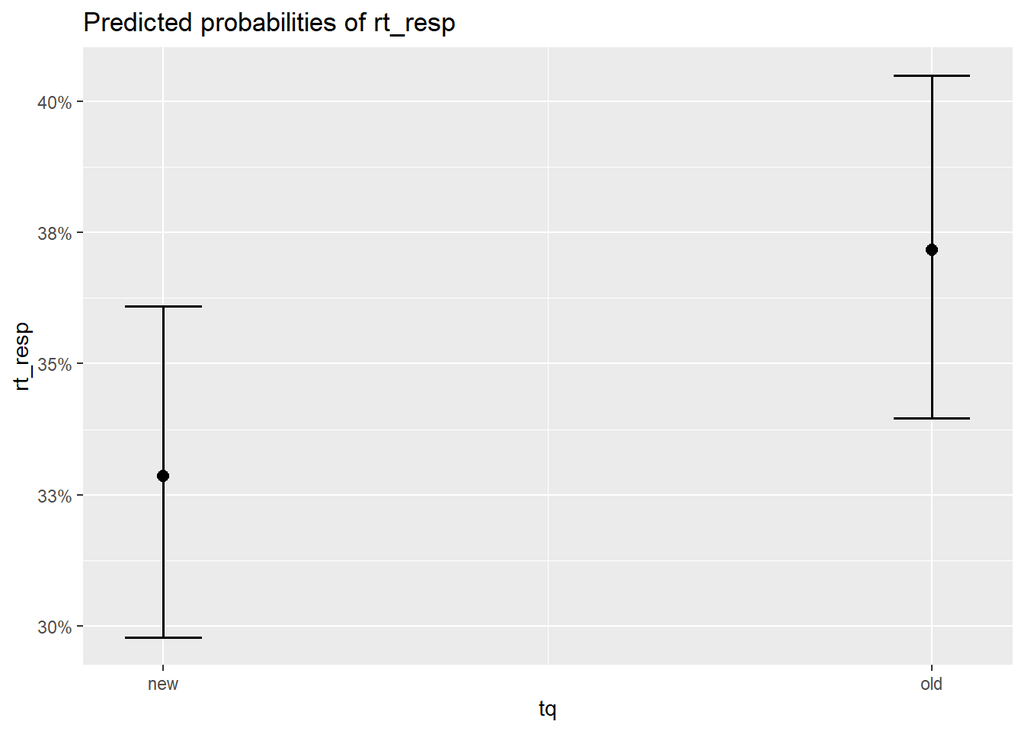

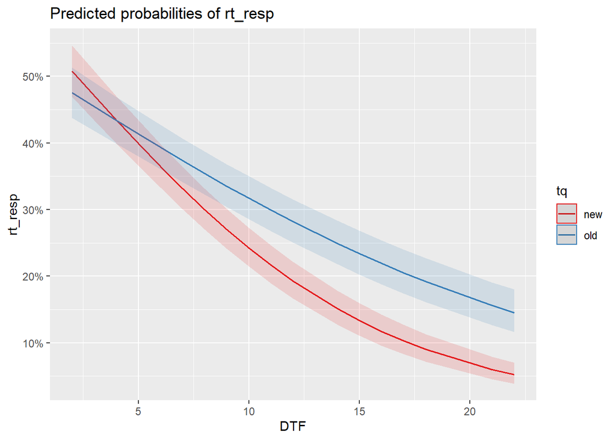

```
## Generalized linear mixed model fit by maximum likelihood (Laplace
##   Approximation) [glmerMod]
##  Family: binomial  ( logit )
## Formula: rt_resp ~ DTAF * tq + (1 | workerId)
##    Data: tdlmm
##
##      AIC      BIC   logLik deviance df.resid
##  10024.8  10059.9  -5007.4  10014.8     8277
##
## Scaled residuals:
##     Min      1Q  Median      3Q     Max
## -2.2448 -0.7659 -0.4541  0.9410  5.2176
##
## Random effects:
##  Groups   Name        Variance Std.Dev.
##  workerId (Intercept) 0.406    0.6372
## Number of obs: 8282, groups:  workerId, 105
##
## Fixed effects:
##             Estimate Std. Error z value Pr(>|z|)
## (Intercept)  2.54185    0.19786  12.847  < 2e-16 ***
## DTAF        -0.24851    0.01487 -16.711  < 2e-16 ***
## tqold       -0.97578    0.24889  -3.920 8.84e-05 ***
## DTAF:tqold   0.08831    0.01953   4.523 6.11e-06 ***
## ---
## Signif. codes:  0 '***' 0.001 '**' 0.01 '*' 0.05 '.' 0.1 ' ' 1
##
## Correlation of Fixed Effects:
##            (Intr) DTAF   tqold
## DTAF       -0.932
## tqold      -0.714  0.739
## DTAF:tqold  0.707 -0.758 -0.981
## optimizer (Nelder_Mead) convergence code: 0 (OK)
## Model failed to converge with max|grad| = 0.00493999 (tol = 0.002, component 1)
```

```
## Package `effects` is not available, but needed for `ggeffect()`. Either install package `effects`, or use `ggpredict()`. Calling `ggpredict()` now.FALSE
```

```
## Data were 'prettified'. Consider using `terms="DTAF [all]"` to get smooth plots.
```

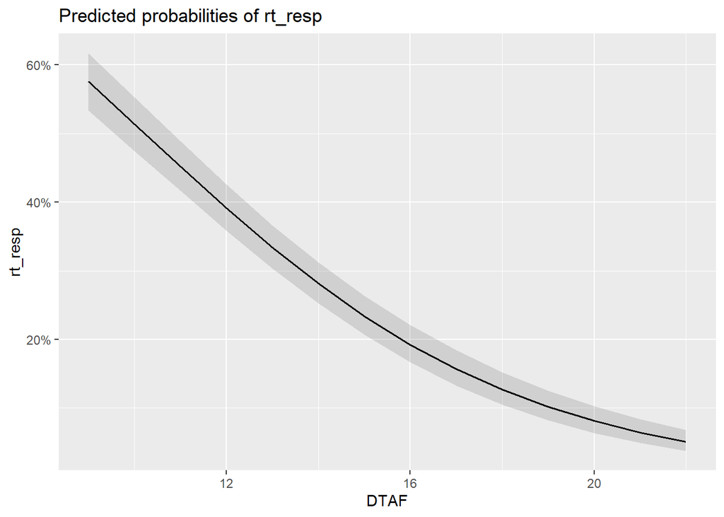

```
## Package `effects` is not available, but needed for `ggeffect()`. Either install package `effects`, or use `ggpredict()`. Calling `ggpredict()` now.FALSE
## Data were 'prettified'. Consider using `terms="DTAF [all]"` to get smooth plots.
```

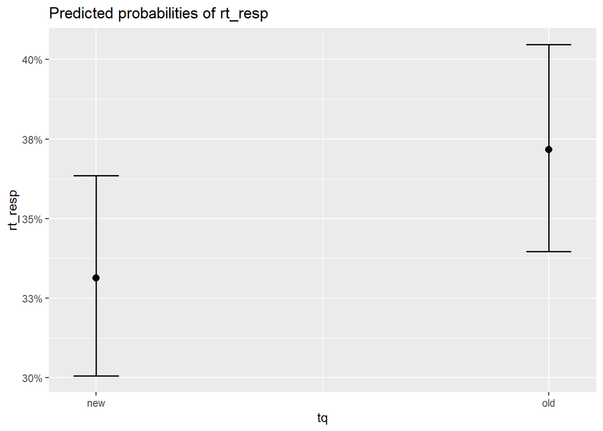

```
## Data were 'prettified'. Consider using `terms="DTAF [all]"` to get smooth plots.
```

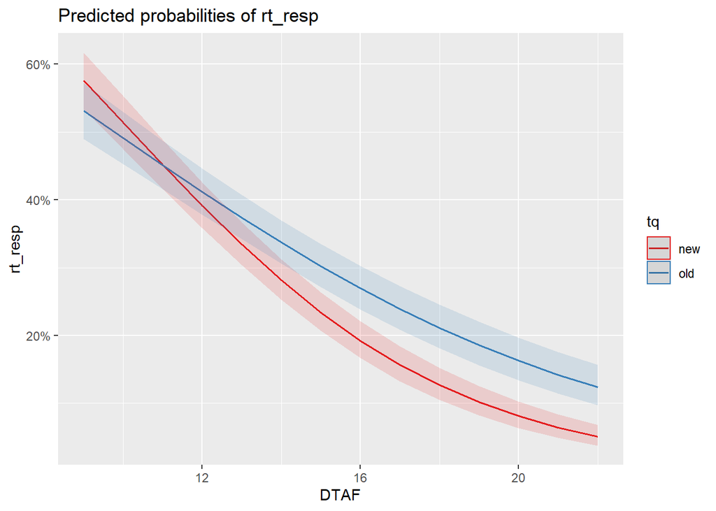

```
## Generalized linear mixed model fit by maximum likelihood (Laplace
##   Approximation) [glmerMod]
##  Family: binomial  ( logit )
## Formula: rt_resp ~ DTAN * tq + (1 | workerId)
##    Data: tdlmm
##
##      AIC      BIC   logLik deviance df.resid
##  10091.3  10126.4  -5040.6  10081.3     8277
##
## Scaled residuals:
##     Min      1Q  Median      3Q     Max
## -2.3967 -0.7518 -0.4781  0.9427  5.8022
##
## Random effects:
##  Groups   Name        Variance Std.Dev.
##  workerId (Intercept) 0.4061   0.6372
## Number of obs: 8282, groups:  workerId, 105
##
## Fixed effects:
##             Estimate Std. Error z value Pr(>|z|)
## (Intercept)  3.55906    0.26397  13.483  < 2e-16 ***
## DTAN        -0.33048    0.02031 -16.274  < 2e-16 ***
## tqold       -1.08230    0.35026  -3.090 0.002001 **
## DTAN:tqold   0.09843    0.02754   3.574 0.000352 ***
## ---
## Signif. codes:  0 '***' 0.001 '**' 0.01 '*' 0.05 '.' 0.1 ' ' 1
##
## Correlation of Fixed Effects:
##            (Intr) DTAN   tqold
## DTAN       -0.962
## tqold      -0.709  0.722
## DTAN:tqold  0.707 -0.734 -0.990
```

```
## Package `effects` is not available, but needed for `ggeffect()`. Either install package `effects`, or use `ggpredict()`. Calling `ggpredict()` now.FALSE
```

```
## Data were 'prettified'. Consider using `terms="DTAN [all]"` to get smooth plots.
```

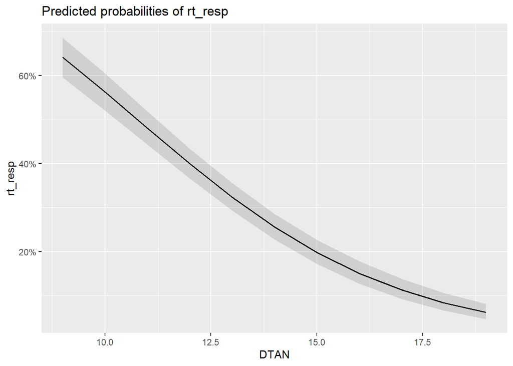

```
## Package `effects` is not available, but needed for `ggeffect()`. Either install package `effects`, or use `ggpredict()`. Calling `ggpredict()` now.FALSE
## Data were 'prettified'. Consider using `terms="DTAN [all]"` to get smooth plots.
```

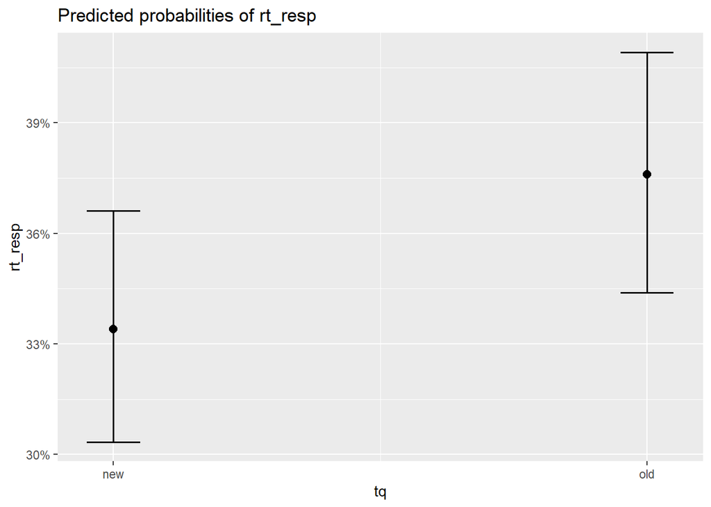

```
## Data were 'prettified'. Consider using `terms="DTAN [all]"` to get smooth plots.
```

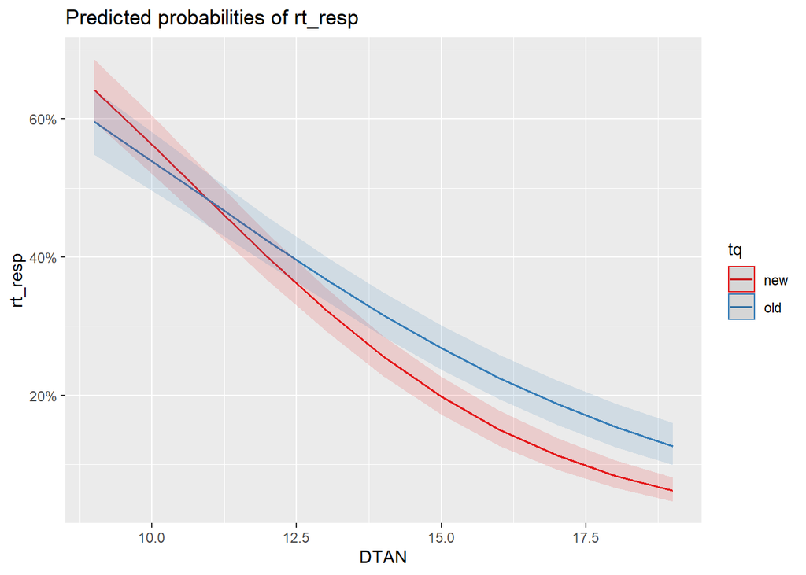

|  | rt_resp |  |  |  | rt_resp |  |  |  | rt_resp |  |  |  |
| --- | --- | --- | --- | --- | --- | --- | --- | --- | --- | --- | --- | --- |
| Predictors | Log-Odds | std. Error | CI | p | Log-Odds | std. Error | CI | p | Log-Odds | std. Error | CI | p |
| (Intercept) | 0.32 | 0.09 | 0.15 – 0.50 | **<0.001** | 2.54 | 0.20 | 2.15 – 2.93 | **<0.001** | 3.56 | 0.26 | 3.04 – 4.08 | **<0.001** |
| DTF | -0.15 | 0.01 | -0.16 – -0.13 | **<0.001** |  |  |  |  |  |  |  |  |
| tq [old] | -0.26 | 0.08 | -0.42 – -0.09 | **0.002** | -0.98 | 0.25 | -1.46 – -0.49 | **<0.001** | -1.08 | 0.35 | -1.77 – -0.40 | **0.002** |
| DTF * tq [old] | 0.06 | 0.01 | 0.04 – 0.08 | **<0.001** |  |  |  |  |  |  |  |  |
| DTAF |  |  |  |  | -0.25 | 0.01 | -0.28 – -0.22 | **<0.001** |  |  |  |  |
| DTAF * tq [old] |  |  |  |  | 0.09 | 0.02 | 0.05 – 0.13 | **<0.001** |  |  |  |  |
| DTAN |  |  |  |  |  |  |  |  | -0.33 | 0.02 | -0.37 – -0.29 | **<0.001** |
| DTAN * tq [old] |  |  |  |  |  |  |  |  | 0.10 | 0.03 | 0.04 – 0.15 | **<0.001** |
| Random Effects |  |  |  |  |  |  |  |  |  |  |  |  |
| σ<sup>2</sup> | 3.29 |  |  |  | 3.29 |  |  |  | 3.29 |  |  |  |
| τ<sub>00</sub> | 0.41 <sub>workerId</sub> |  |  |  | 0.41 <sub>workerId</sub> |  |  |  | 0.41 <sub>workerId</sub> |  |  |  |
| ICC | 0.11 |  |  |  | 0.11 |  |  |  | 0.11 |  |  |  |
| N | 105 <sub>workerId</sub> |  |  |  | 105 <sub>workerId</sub> |  |  |  | 105 <sub>workerId</sub> |  |  |  |
| Observations | 8282 |  |  |  | 8282 |  |  |  | 8282 |  |  |  |
| Marginal R<sup>2</sup> / Conditional R<sup>2</sup> | 0.105 / 0.204 |  |  |  | 0.098 / 0.197 |  |  |  | 0.077 / 0.179 |  |  |  |
| AIC | 10014.664 |  |  |  | 10024.780 |  |  |  | 10091.257 |  |  |  |
| AICc | 10014.671 |  |  |  | 10024.787 |  |  |  | 10091.265 |  |  |  |

### Models #2 - with random slope (trial quality)

Logistic mixed regression for the test phase. Does difference from prototypes or familiarity/novelty have an effect on correct categorization in the test phase?

```
## Generalized linear mixed model fit by maximum likelihood (Laplace
##   Approximation) [glmerMod]
##  Family: binomial  ( logit )
## Formula: rt_resp ~ DTF * tq + (tq | workerId)
##    Data: tdlmm
## Control: lmerControl(optCtrl = list(xtol_abs = 1e-08, ftol_abs = 1e-08,
##     maxeval = 1e+05))
##
##      AIC      BIC   logLik deviance df.resid
##  10010.0  10059.2  -4998.0   9996.0     8275
##
## Scaled residuals:
##     Min      1Q  Median      3Q     Max
## -2.5459 -0.7654 -0.4499  0.9391  7.4977
##
## Random effects:
##  Groups   Name        Variance Std.Dev. Corr
##  workerId (Intercept) 0.53932  0.7344
##           tqold       0.04872  0.2207   -0.82
## Number of obs: 8282, groups:  workerId, 105
##
## Fixed effects:
##              Estimate Std. Error z value Pr(>|z|)
## (Intercept)  0.322943   0.095277   3.390  0.00070 ***
## DTF         -0.148796   0.008838 -16.836  < 2e-16 ***
## tqold       -0.251523   0.085683  -2.935  0.00333 **
## DTF:tqold    0.066209   0.011214   5.904 3.54e-09 ***
## ---
## Signif. codes:  0 '***' 0.001 '**' 0.01 '*' 0.05 '.' 0.1 ' ' 1
##
## Correlation of Fixed Effects:
##           (Intr) DTF    tqold
## DTF       -0.534
## tqold     -0.636  0.593
## DTF:tqold  0.420 -0.788 -0.775
## optimizer (nloptwrap) convergence code: 0 (OK)
## Model failed to converge with max|grad| = 0.00272318 (tol = 0.002, component 1)
```

```
## Package `effects` is not available, but needed for `ggeffect()`. Either install package `effects`, or use `ggpredict()`. Calling `ggpredict()` now.FALSE
```

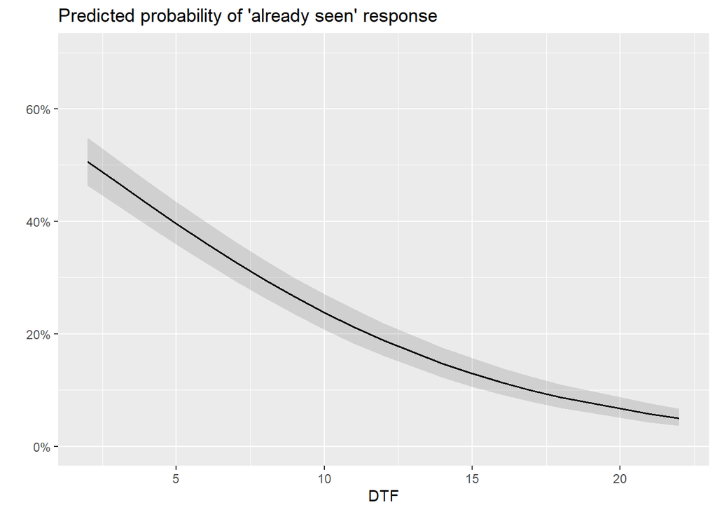

```
## Package `effects` is not available, but needed for `ggeffect()`. Either install package `effects`, or use `ggpredict()`. Calling `ggpredict()` now.FALSE
```

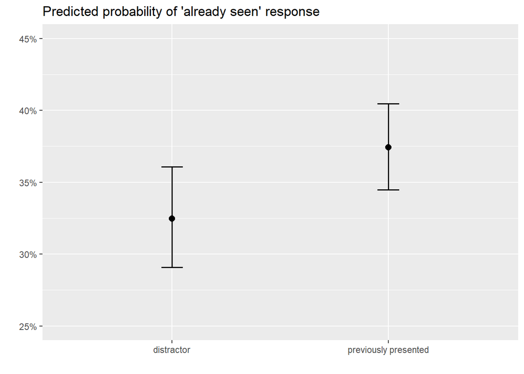

```
## which will replace the existing scale.
```

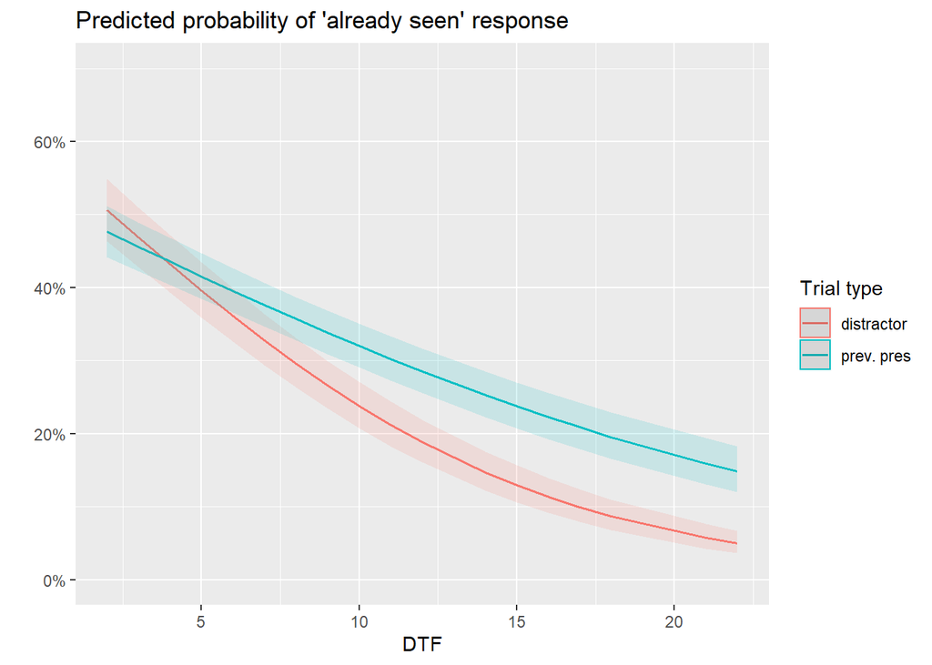

```
## Generalized linear mixed model fit by maximum likelihood (Laplace
##   Approximation) [glmerMod]
##  Family: binomial  ( logit )
## Formula: rt_resp ~ DTAF * tq + (tq | workerId)
##    Data: tdlmm
##
##      AIC      BIC   logLik deviance df.resid
##  10021.1  10070.2  -5003.5  10007.1     8275
##
## Scaled residuals:
##     Min      1Q  Median      3Q     Max
## -2.4427 -0.7662 -0.4541  0.9397  5.6337
##
## Random effects:
##  Groups   Name        Variance Std.Dev. Corr
##  workerId (Intercept) 0.52618  0.7254
##           tqold       0.04346  0.2085   -0.82
## Number of obs: 8282, groups:  workerId, 105
##
## Fixed effects:
##             Estimate Std. Error z value Pr(>|z|)
## (Intercept)  2.57279    0.20259  12.700  < 2e-16 ***
## DTAF        -0.25215    0.01505 -16.751  < 2e-16 ***
## tqold       -1.02223    0.25072  -4.077 4.56e-05 ***
## DTAF:tqold   0.09392    0.01966   4.776 1.79e-06 ***
## ---
## Signif. codes:  0 '***' 0.001 '**' 0.01 '*' 0.05 '.' 0.1 ' ' 1
##
## Correlation of Fixed Effects:
##            (Intr) DTAF   tqold
## DTAF       -0.919
## tqold      -0.732  0.742
## DTAF:tqold  0.703 -0.765 -0.977
```

```
## Package `effects` is not available, but needed for `ggeffect()`. Either install package `effects`, or use `ggpredict()`. Calling `ggpredict()` now.FALSE
```

```
## Data were 'prettified'. Consider using `terms="DTAF [all]"` to get smooth plots.
```

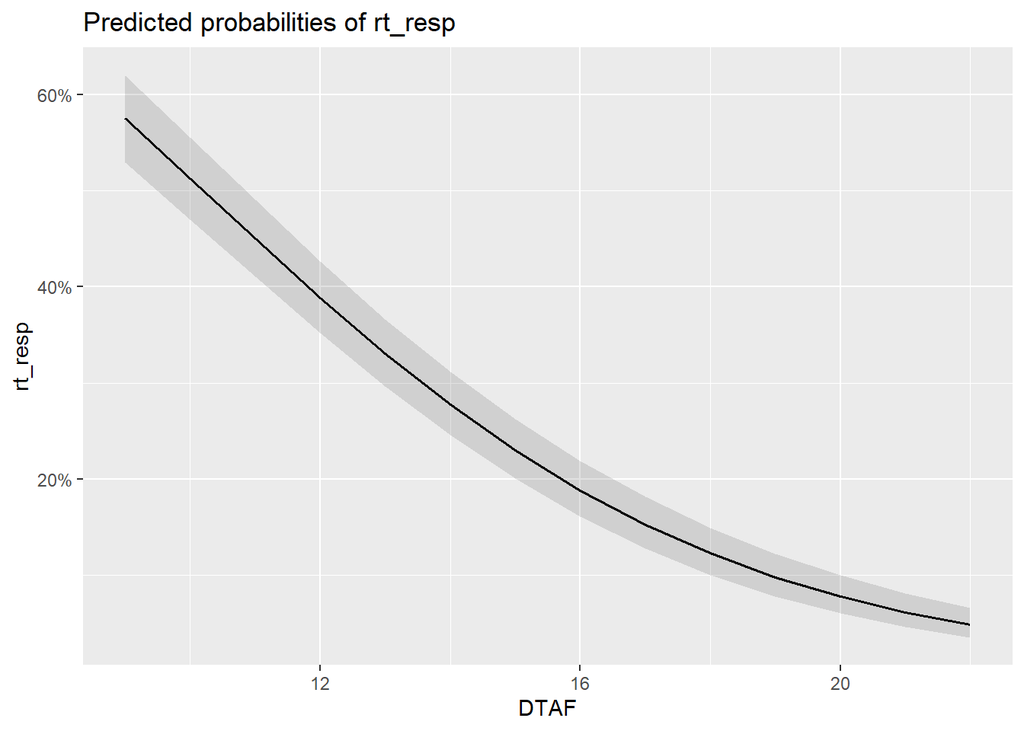

```
## Package `effects` is not available, but needed for `ggeffect()`. Either install package `effects`, or use `ggpredict()`. Calling `ggpredict()` now.FALSE
## Data were 'prettified'. Consider using `terms="DTAF [all]"` to get smooth plots.
```

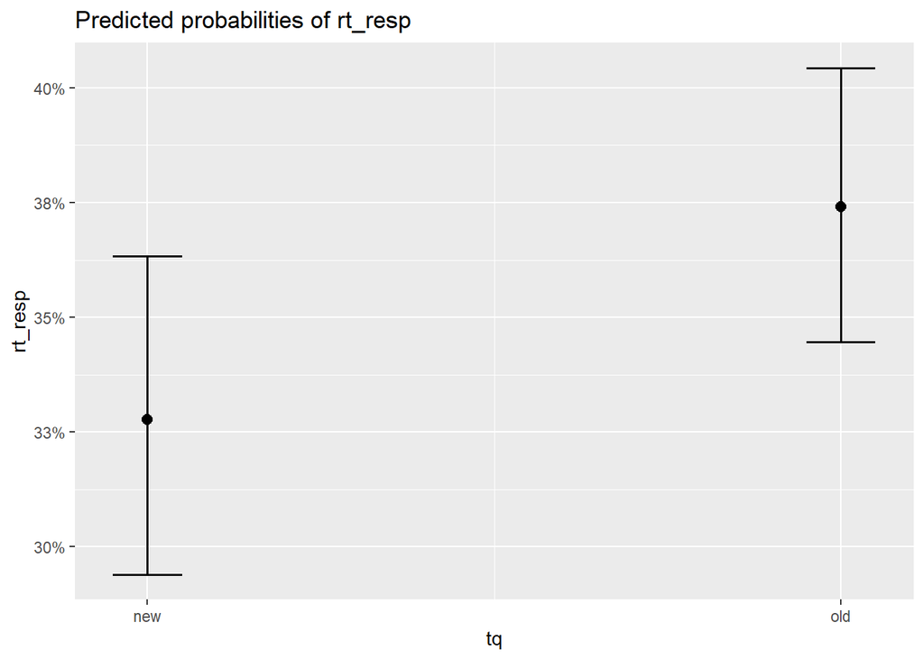

```
## Data were 'prettified'. Consider using `terms="DTAF [all]"` to get smooth plots.
```

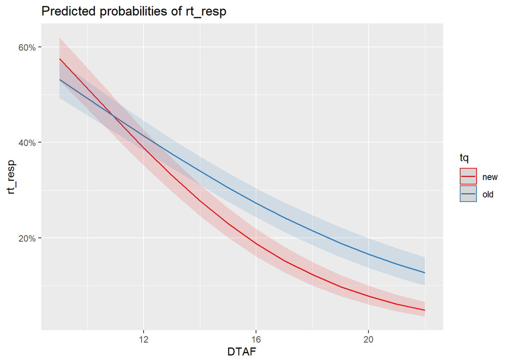

```
## Generalized linear mixed model fit by maximum likelihood (Laplace
##   Approximation) [glmerMod]
##  Family: binomial  ( logit )
## Formula: rt_resp ~ DTAN * tq + (tq | workerId)
##    Data: tdlmm
##
##      AIC      BIC   logLik deviance df.resid
##  10088.5  10137.6  -5037.2  10074.5     8275
##
## Scaled residuals:
##     Min      1Q  Median      3Q     Max
## -2.5918 -0.7522 -0.4779  0.9434  6.5465
##
## Random effects:
##  Groups   Name        Variance Std.Dev. Corr
##  workerId (Intercept) 0.5179   0.7196
##           tqold       0.0418   0.2045   -0.79
## Number of obs: 8282, groups:  workerId, 105
##
## Fixed effects:
##             Estimate Std. Error z value Pr(>|z|)
## (Intercept)  3.60694    0.26897  13.410  < 2e-16 ***
## DTAN        -0.33544    0.02059 -16.292  < 2e-16 ***
## tqold       -1.15912    0.35273  -3.286 0.001016 **
## DTAN:tqold   0.10636    0.02777   3.831 0.000128 ***
## ---
## Signif. codes:  0 '***' 0.001 '**' 0.01 '*' 0.05 '.' 0.1 ' ' 1
##
## Correlation of Fixed Effects:
##            (Intr) DTAN   tqold
## DTAN       -0.956
## tqold      -0.722  0.729
## DTAN:tqold  0.708 -0.741 -0.988
```

```
## Package `effects` is not available, but needed for `ggeffect()`. Either install package `effects`, or use `ggpredict()`. Calling `ggpredict()` now.FALSE
```

```
## Data were 'prettified'. Consider using `terms="DTAN [all]"` to get smooth plots.
```

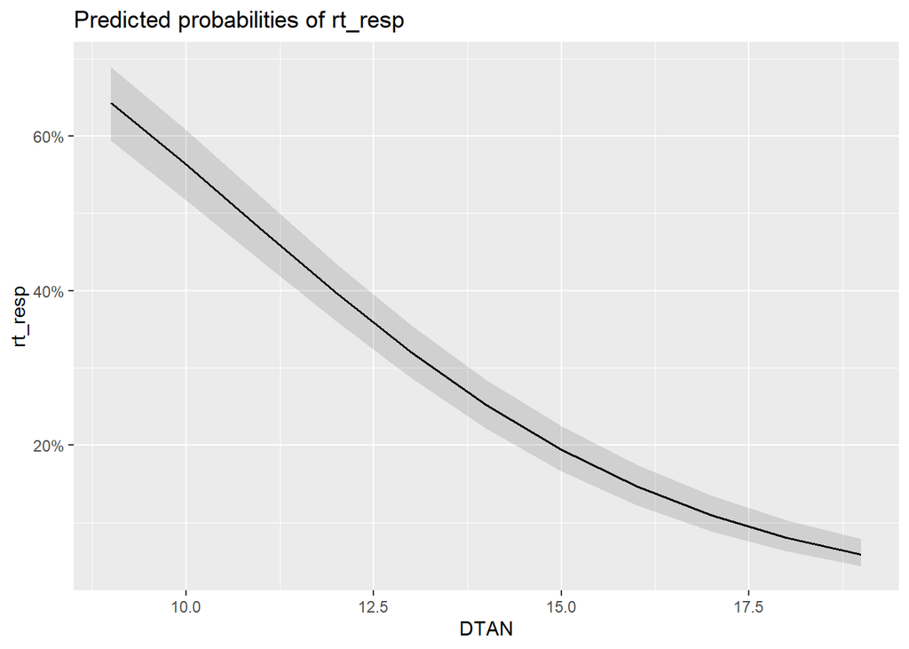

```
## Package `effects` is not available, but needed for `ggeffect()`. Either install package `effects`, or use `ggpredict()`. Calling `ggpredict()` now.FALSE
## Data were 'prettified'. Consider using `terms="DTAN [all]"` to get smooth plots.
```

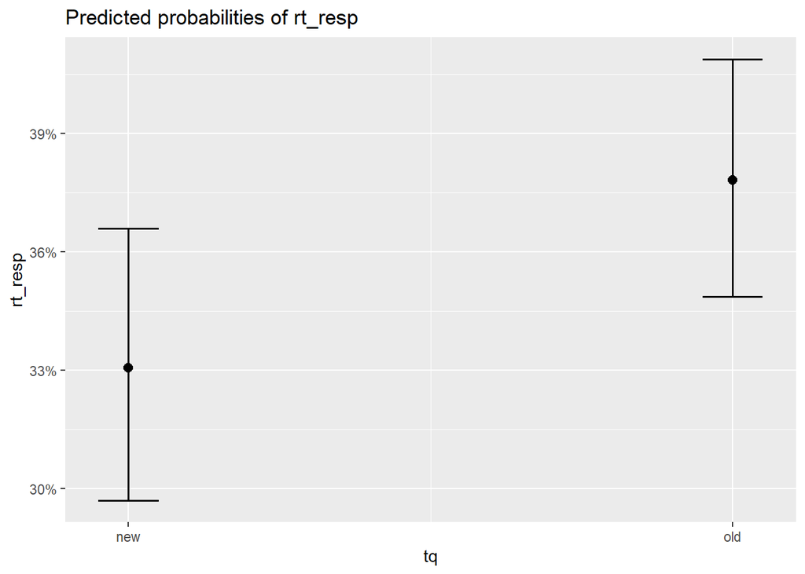

```
## Data were 'prettified'. Consider using `terms="DTAN [all]"` to get smooth plots.
```

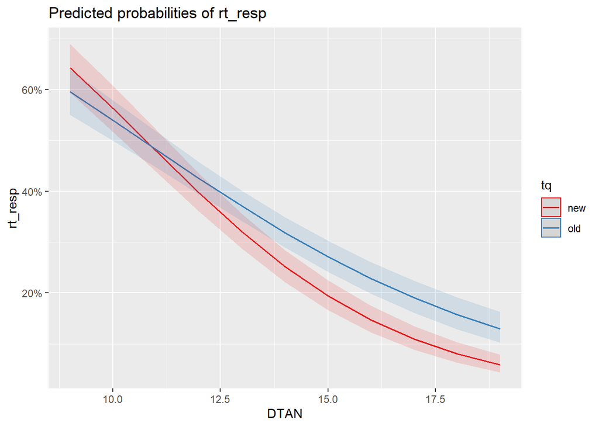

|  | rt_resp |  |  |  | rt_resp |  |  |  | rt_resp |  |  |  |
| --- | --- | --- | --- | --- | --- | --- | --- | --- | --- | --- | --- | --- |
| Predictors | Log-Odds | std. Error | CI | p | Log-Odds | std. Error | CI | p | Log-Odds | std. Error | CI | p |
| (Intercept) | 0.32 | 0.10 | 0.14 – 0.51 | **0.001** | 2.57 | 0.20 | 2.18 – 2.97 | **<0.001** | 3.61 | 0.27 | 3.08 – 4.13 | **<0.001** |
| DTF | -0.15 | 0.01 | -0.17 – -0.13 | **<0.001** |  |  |  |  |  |  |  |  |
| tq [old] | -0.25 | 0.09 | -0.42 – -0.08 | **0.003** | -1.02 | 0.25 | -1.51 – -0.53 | **<0.001** | -1.16 | 0.35 | -1.85 – -0.47 | **0.001** |
| DTF * tq [old] | 0.07 | 0.01 | 0.04 – 0.09 | **<0.001** |  |  |  |  |  |  |  |  |
| DTAF |  |  |  |  | -0.25 | 0.02 | -0.28 – -0.22 | **<0.001** |  |  |  |  |
| DTAF * tq [old] |  |  |  |  | 0.09 | 0.02 | 0.06 – 0.13 | **<0.001** |  |  |  |  |
| DTAN |  |  |  |  |  |  |  |  | -0.34 | 0.02 | -0.38 – -0.30 | **<0.001** |
| DTAN * tq [old] |  |  |  |  |  |  |  |  | 0.11 | 0.03 | 0.05 – 0.16 | **<0.001** |
| Random Effects |  |  |  |  |  |  |  |  |  |  |  |  |
| σ<sup>2</sup> | 3.29 |  |  |  | 3.29 |  |  |  | 3.29 |  |  |  |
| τ<sub>00</sub> | 0.54 <sub>workerId</sub> |  |  |  | 0.53 <sub>workerId</sub> |  |  |  | 0.52 <sub>workerId</sub> |  |  |  |
| τ<sub>11</sub> | 0.05 <sub>workerId.tqold</sub> |  |  |  | 0.04 <sub>workerId.tqold</sub> |  |  |  | 0.04 <sub>workerId.tqold</sub> |  |  |  |
| ρ<sub>01</sub> | -0.82 <sub>workerId</sub> |  |  |  | -0.82 <sub>workerId</sub> |  |  |  | -0.79 <sub>workerId</sub> |  |  |  |
| ICC | 0.12 |  |  |  | 0.11 |  |  |  | 0.11 |  |  |  |
| N | 105 <sub>workerId</sub> |  |  |  | 105 <sub>workerId</sub> |  |  |  | 105 <sub>workerId</sub> |  |  |  |
| Observations | 8282 |  |  |  | 8282 |  |  |  | 8282 |  |  |  |
| Marginal R<sup>2</sup> / Conditional R<sup>2</sup> | 0.107 / 0.210 |  |  |  | 0.099 / 0.202 |  |  |  | 0.078 / 0.183 |  |  |  |
| AIC | 10009.999 |  |  |  | 10021.065 |  |  |  | 10088.465 |  |  |  |
| AICc | 10010.012 |  |  |  | 10021.079 |  |  |  | 10088.478 |  |  |  |